# Evolución del COVID-19 en España

Pedro Garrido Rodríguez

30 de abril de 2020

```r
setwd("~/COVID-19/")
library(ggplot2); library(reshape2)
```

# 1 Obtención de los datos

Para analizar la evolución del SARS-CoV-2 en España se obtiene información sobre casos positivos, hospitalizados, fallecidos y altas hospitalarias. Son datos diarios, agregados y desglosados por comunidad autónoma. Estos datos se obtienen del [GitHub de datadista](https://github.com/datadista/datasets/tree/master/COVID%2019) y proceden de los informes oficiales del [Ministerio de Sanidad](https://www.mscbs.gob.es/profesionales/saludPublica/ccayes/alertasActual/nCov-China/situacionActual.htm) y el [Instituto de Salud Carlos III](https://covid19.isciii.es/).

```r
if(dir.exists("Datos") == F) {
  dir.create("Datos")
}
```

```bash
cd ./Datos/

# Casos agregados
wget -N https://raw.githubusercontent.com/datadista/datasets/master/COVID%2019/ccaa_covid19_casos.csv

# Altas agregadas
wget -N https://raw.githubusercontent.com/datadista/datasets/master/COVID%2019/ccaa_covid19_altas.csv

# Fallecidos agregados
wget -N https://raw.githubusercontent.com/datadista/datasets/master/COVID%2019/ccaa_covid19_fallecidos.csv

# Hospitalizados agregados
wget -N https://raw.githubusercontent.com/datadista/datasets/master/COVID%2019/ccaa_covid19_hospitalizados.csv

cd ..
```

```r
casos <- read.csv("./Datos/ccaa_covid19_casos.csv", check.names = F)
# Se elimina la primera columna porque contiene el código de provincia y no es necesario
casos <- casos[,2:ncol(casos)]

hospitalizados <- read.csv("./Datos/ccaa_covid19_hospitalizados.csv", check.names = F)
hospitalizados <- hospitalizados[,2:ncol(hospitalizados)]

fallecidos <- read.csv("./Datos/ccaa_covid19_fallecidos.csv", check.names = F)
fallecidos <- fallecidos[,2:ncol(fallecidos)]

altas <- read.csv("./Datos/ccaa_covid19_altas.csv", check.names = F)
altas <- altas[,2:ncol(altas)]
```

# 2 Procesamiento de los datos

Para poder manejar los datos obtenidos se realizan una serie de transformaciones estructurales sobre los *datasets*.

1. Apilar los datos para facilitar su manejo.

```r
casos.stacked <- melt(casos, id.vars = c("CCAA"))
names(casos.stacked) <- c("CCAA", "Fecha", "Casos")

hospitalizados.stacked <- melt(hospitalizados, id.vars = c("CCAA"))
names(hospitalizados.stacked) <- c("CCAA", "Fecha", "Hospitalizados")

fallecidos.stacked <- melt(fallecidos, id.vars = c("CCAA"))
names(fallecidos.stacked) <- c("CCAA", "Fecha", "Fallecidos")

altas.stacked <- melt(altas, id.vars = c("CCAA"))
names(altas.stacked) <- c("CCAA", "Fecha", "Altas")
```

2. Crear un *dataset* único con los datos conjuntos.

```r
df <- data.frame(
  "Fecha" = casos.stacked$Fecha,
  "CCAA" = casos.stacked$CCAA,
  "Casos" = casos.stacked$Casos,
  "Fallecidos" = c(rep(0, (nrow(casos.stacked) - nrow(fallecidos.stacked))), fallecidos.stacked$Fallecidos),
  "Hospitalizados" = c(rep(0, (nrow(casos.stacked) - nrow(hospitalizados.stacked))), hospitalizados.stacked$Hospitalizados),
  "Altas" = c(rep(0, (nrow(casos.stacked) - nrow(altas.stacked))), altas.stacked$Altas)
)
```

3. Crear *datasets* para el Estado y la CARM.

```r
df.total <- subset(df, CCAA == "Total")
df.total <- df.total[,c(1, 3:6)]
df.total.stacked <- melt(df.total, id.vars = "Fecha")

df.CARM <- subset(df, CCAA == "Murcia")
df.CARM <- df.CARM[,c(1, 3:6)]
df.CARM.stacked <- melt(df.CARM, id.vars = "Fecha")
```

4. Crear *datasets* auxiliares para las representaciones de barras. Estos *datasets* no incluyen el total, ya que la propia representación lo calcula por suma de las CCAA.

```r
casos.stacked.aux <- subset(casos.stacked, CCAA != "Total")
hospitalizados.stacked.aux <- subset(hospitalizados.stacked, CCAA != "Total")
fallecidos.stacked.aux <- subset(fallecidos.stacked, CCAA != "Total")
altas.stacked.aux <- subset(altas.stacked, CCAA != "Total")
```

5. Cálculo de velocidades de crecimiento diario de nuevos casos.

```r
# Velocidades en el conjunto del Estado
velocidades.casos.ESP <- rep(0, nrow(df.total))
for (i in 2:nrow(df.total)) {
  velocidades.casos.ESP[i] = df.total$Casos[i] - df.total$Casos[i - 1]
}

velocidades.fallecidos.ESP <- rep(0, nrow(df.total))
for (i in 2:nrow(df.total)) {
  velocidades.fallecidos.ESP[i] = df.total$Fallecidos[i] - df.total$Fallecidos[i - 1]
}

velocidades.hospitalizados.ESP <- rep(0, nrow(df.total))
for (i in 2:nrow(df.total)) {
  velocidades.hospitalizados.ESP[i] =
    df.total$Hospitalizados[i] - df.total$Hospitalizados[i - 1]
}

velocidades.altas.ESP <- rep(0, nrow(df.total))
for (i in 2:nrow(df.total)) {
  velocidades.altas.ESP[i] = df.total$Altas[i] - df.total$Altas[i - 1]
}

velocidades.ESP <- data.frame(
  "Fecha" = as.vector(df.total$Fecha),
  "Positivos" = velocidades.casos.ESP,
  "Fallecidos" = velocidades.fallecidos.ESP,
  "Hospitalizados" = velocidades.hospitalizados.ESP,
  "Altas" = velocidades.altas.ESP
)

# Velocidades en la CARM
velocidades.casos.CARM <- rep(0, nrow(df.CARM))
for (i in 2:nrow(df.CARM)) {
  velocidades.casos.CARM[i] = df.CARM$Casos[i] - df.CARM$Casos[i - 1]
}

velocidades.fallecidos.CARM <- rep(0, nrow(df.CARM))
for (i in 2:nrow(df.CARM)) {
  velocidades.fallecidos.CARM[i] = df.CARM$Fallecidos[i] - df.CARM$Fallecidos[i - 1]
}

velocidades.hospitalizados.CARM <- rep(0, nrow(df.CARM))
for (i in 2:nrow(df.CARM)) {
  velocidades.hospitalizados.CARM[i] =
    df.CARM$Hospitalizados[i] - df.CARM$Hospitalizados[i - 1]
}

velocidades.altas.CARM <- rep(0, nrow(df.CARM))
for (i in 2:nrow(df.CARM)) {
  velocidades.altas.CARM[i] = df.CARM$Altas[i] - df.CARM$Altas[i - 1]
}

velocidades.CARM <- data.frame(
  "Fecha" = as.vector(df.CARM$Fecha),
  "Positivos" = velocidades.casos.CARM,
  "Fallecidos" = velocidades.fallecidos.CARM,
  "Hospitalizados" = velocidades.hospitalizados.CARM,
  "Altas" = velocidades.altas.CARM
)

# Crear datasets apilados para facilitar su tratamiento
velocidades.ESP.stacked <- melt(velocidades.ESP, id.vars = "Fecha")
velocidades.CARM.stacked <- melt(velocidades.CARM, id.vars = "Fecha")
```

# 3 Gráficos

Se van a generar gráficos de la evolución global del virus a nivel del Estado y de la Región de Murcia. Asimismo, se obtendrán representaciones sobre la evolución de la pandemia en el Estado desglosada por factor, esto es:

- número de positivos
- Número de hospitalizados
- Número de fallecidos
- Número de altas hospitalarias.

## 3.1 Código

### 3.1.1 Datos acumulados

#### 3.1.1.1 Gráficos globales

```r
global.ESP <- ggplot(df.total.stacked, aes(x = Fecha)) +
  geom_bar(aes(y = value, fill = variable), stat = "identity", position = "dodge2") +
  geom_vline(xintercept = "2020-03-14", linetype = "dashed", color = "red") +
  geom_vline(xintercept = "2020-03-26", linetype = "dashed", color = "blue") +
  geom_vline(xintercept = "2020-04-13", linetype = "dashed", color = "green") +
  theme(axis.text.x = element_text(angle = 90), legend.title=element_blank()) +
  labs(title = "Evolución del COVID-19 en España",
       subtitle = "Datos agregados",
       x = "Fecha", y = "Número de pacientes")

global.raw <- ggplot(df.total.stacked, aes(x = Fecha, y = value, group = variable, color = variable)) +
  geom_line() + geom_point() +
  geom_vline(xintercept = "2020-03-14", linetype = "dashed", color = "red") +
  geom_vline(xintercept = "2020-03-26", linetype = "dashed", color = "blue") +
  geom_vline(xintercept = "2020-04-13", linetype = "dashed", color = "green") +
  theme(axis.text.x = element_text(angle = 90), legend.title=element_blank()) +
  labs(title = "Evolución del COVID-19 en España",
       x = "Fecha", y = "Número de pacientes")

global.suavizado <- ggplot(df.total.stacked, aes(x = Fecha, y = value, group = variable, color = variable)) +
  geom_smooth(alpha = 0.1) +
  geom_vline(xintercept = "2020-03-14", linetype = "dashed", color = "red") +
  geom_vline(xintercept = "2020-03-26", linetype = "dashed", color = "blue") +
  geom_vline(xintercept = "2020-04-13", linetype = "dashed", color = "green") +
  theme(axis.text.x = element_text(angle = 90), legend.title=element_blank()) +
  labs(title = "Evolución del COVID-19 en España",
       x = "Fecha", y = "Número de pacientes")

global.CARM <- ggplot(df.CARM.stacked, aes(x = Fecha)) +
  geom_bar(aes(y = value, fill = variable), stat = "identity", position = "dodge2") +
  geom_vline(xintercept = "2020-03-14", linetype = "dashed", color = "red") +
  geom_vline(xintercept = "2020-03-26", linetype = "dashed", color = "blue") +
  geom_vline(xintercept = "2020-04-13", linetype = "dashed", color = "green") +
  theme(axis.text.x = element_text(angle = 90), legend.title=element_blank()) +
  labs(title = "Evolución del COVID-19 en la Región de Murcia",
       subtitle = "Datos agregados",
       x = "Fecha", y = "Número de pacientes")

CARM.raw <- ggplot(df.CARM.stacked, aes(x = Fecha, y = value, group = variable, color = variable)) +
  geom_line() + geom_point() +
  geom_vline(xintercept = "2020-03-14", linetype = "dashed", color = "red") +
  geom_vline(xintercept = "2020-03-26", linetype = "dashed", color = "blue") +
  geom_vline(xintercept = "2020-04-13", linetype = "dashed", color = "green") +
  theme(axis.text.x = element_text(angle = 90), legend.title=element_blank()) +
  labs(title = "Evolución del COVID-19 en la Región de Murcia",
       x = "Fecha", y = "Número de pacientes")

CARM.suavizado <- ggplot(df.CARM.stacked, aes(x = Fecha, y = value, group = variable, color = variable)) +
  geom_smooth(alpha = 0.1) +
  geom_vline(xintercept = "2020-03-14", linetype = "dashed", color = "red") +
  geom_vline(xintercept = "2020-03-26", linetype = "dashed", color = "blue") +
  geom_vline(xintercept = "2020-04-13", linetype = "dashed", color = "green") +
  theme(axis.text.x = element_text(angle = 90), legend.title=element_blank()) +
  labs(title = "Evolución del COVID-19 en la Región de Murcia",
       x = "Fecha", y = "Número de pacientes")
```

#### 3.1.1.2 Gráficos de líneas

```r
casos.line <- ggplot(casos.stacked, aes(x = Fecha, y = Casos, group = CCAA, color = CCAA)) +
  geom_line() + geom_point() +
  geom_vline(xintercept = "2020-03-14", linetype = "dashed", color = "red") +
  geom_vline(xintercept = "2020-03-26", linetype = "dashed", color = "blue") +
  geom_vline(xintercept = "2020-04-13", linetype = "dashed", color = "green") +
  theme(axis.text.x = element_text(angle = 90), legend.title=element_blank()) +
  labs(title = "Evolución del COVID-19 en España por CCAA",
       subtitle = "Número de casos agregados",
       x = "Fecha", y = "Positivos")

hospitalizados.line <- ggplot(hospitalizados.stacked,
                              aes(x = Fecha, y = Hospitalizados, group = CCAA, color = CCAA)) +
  geom_line() + geom_point() +
  geom_vline(xintercept = "2020-03-26", linetype = "dashed", color = "blue") +
  geom_vline(xintercept = "2020-04-13", linetype = "dashed", color = "green") +
  theme(axis.text.x = element_text(angle = 90), legend.title=element_blank()) +
  labs(title = "Evolución del COVID-19 en España por CCAA",
       subtitle = "Número de hospitalizados agregados",
       x = "Fecha", y = "Hospitalizados")

fallecidos.line<- ggplot(fallecidos.stacked,
                         aes(x = Fecha, y = Fallecidos, group = CCAA, color = CCAA)) +
  geom_line() + geom_point() +
  geom_vline(xintercept = "2020-03-14", linetype = "dashed", color = "red") +
  geom_vline(xintercept = "2020-03-26", linetype = "dashed", color = "blue") +
  geom_vline(xintercept = "2020-04-13", linetype = "dashed", color = "green") +
  theme(axis.text.x = element_text(angle = 90)) +
  labs(title = "Evolución del COVID-19 en España por CCAA",
       subtitle = "Número de fallecidos agregados",
       x = "Fecha", y = "Fallecidos")

altas.line <- ggplot(altas.stacked, aes(x = Fecha, y = Altas, group = CCAA, color = CCAA)) +
  geom_line() + geom_point() +
  geom_vline(xintercept = "2020-03-14", linetype = "dashed", color = "red") +
  geom_vline(xintercept = "2020-03-26", linetype = "dashed", color = "blue") +
  geom_vline(xintercept = "2020-04-13", linetype = "dashed", color = "green") +
  theme(axis.text.x = element_text(angle = 90), legend.title=element_blank()) +
  labs(title = "Evolución del COVID-19 en España por CCAA",
       subtitle = "Número de altas hospitalarias agregadas",
       x = "Fecha", y = "Altas hospitalarias")
```

#### 3.1.1.3 Gráficos de barras

```r
casos.bar <- ggplot(casos.stacked.aux, aes(x = Fecha)) +
  geom_bar(aes(y = Casos, fill = CCAA), color = "black", stat = "identity") +
  geom_vline(xintercept = "2020-03-14", linetype = "dashed", color = "red") +
  geom_vline(xintercept = "2020-03-26", linetype = "dashed", color = "blue") +
  geom_vline(xintercept = "2020-04-13", linetype = "dashed", color = "green") +
  theme(axis.text.x = element_text(angle = 90), legend.title=element_blank()) +
  labs(title = "Evolución del COVID-19 en España por CCAA",
       subtitle = "Número de casos agregados",
       x = "Fecha", y = "Positivos")

hospitalizados.bar <- ggplot(hospitalizados.stacked.aux, aes(x = Fecha)) +
  geom_bar(aes(y = Hospitalizados, fill = CCAA), color = "black", stat = "identity") +
  geom_vline(xintercept = "2020-03-26", linetype = "dashed", color = "blue") +
  geom_vline(xintercept = "2020-04-13", linetype = "dashed", color = "green") +
  theme(axis.text.x = element_text(angle = 90), legend.title=element_blank()) +
  labs(title = "Evolución del COVID-19 en España por CCAA",
       subtitle = "Número de hospitalizados agregados",
       x = "Fecha", y = "Hospitalizados")

fallecidos.bar <- ggplot(fallecidos.stacked.aux, aes(x = Fecha)) +
  geom_bar(aes(y = Fallecidos, fill = CCAA), color = "black", stat = "identity") +
  geom_vline(xintercept = "2020-03-14", linetype = "dashed", color = "red") +
  geom_vline(xintercept = "2020-03-26", linetype = "dashed", color = "blue") +
  geom_vline(xintercept = "2020-04-13", linetype = "dashed", color = "green") +
  theme(axis.text.x = element_text(angle = 90), legend.title=element_blank()) +
  labs(title = "Evolución del COVID-19 en España por CCAA",
       subtitle = "Número de fallecidos agregados",
       x = "Fecha", y = "Fallecidos")

altas.bar <- ggplot(altas.stacked.aux, aes(x = Fecha)) +
  geom_bar(aes(y = Altas, fill = CCAA), color = "black", stat = "identity") +
  geom_vline(xintercept = "2020-03-14", linetype = "dashed", color = "red") +
  geom_vline(xintercept = "2020-03-26", linetype = "dashed", color = "blue") +
  geom_vline(xintercept = "2020-04-13", linetype = "dashed", color = "green") +
  theme(axis.text.x = element_text(angle = 90), legend.title=element_blank()) +
  labs(title = "Evolución del COVID-19 en España por CCAA",
       subtitle = "Número de altas hospitalarias agregadas",
       x = "Fecha", y = "Altas hospitalarias")
```

### 3.1.2 Velocidades de evolución

```r
vel.plot.raw <- ggplot(velocidades.ESP.stacked, aes(x = Fecha, y = value, group = variable, color = variable)) +
  geom_line() +
  geom_vline(xintercept = "2020-03-14", linetype = "dashed", color = "red") +
  geom_vline(xintercept = "2020-03-26", linetype = "dashed", color = "blue") +
  geom_vline(xintercept = "2020-04-13", linetype = "dashed", color = "green") +
  theme(axis.text.x = element_text(angle = 90), legend.title=element_blank()) +
  labs(title = "Evolución del COVID-19 en España",
       subtitle = "Velocidad de expansión",
       x = "Fecha", y = "Casos / día"
       )

vel.plot.suavizado <- ggplot(velocidades.ESP.stacked, aes(x = Fecha, y = value, group = variable, color = variable)) +
  geom_smooth(alpha = 0.1) +
  geom_vline(xintercept = "2020-03-14", linetype = "dashed", color = "red") +
  geom_vline(xintercept = "2020-03-26", linetype = "dashed", color = "blue") +
  geom_vline(xintercept = "2020-04-13", linetype = "dashed", color = "green") +
  theme(axis.text.x = element_text(angle = 90), legend.title=element_blank()) +
  labs(title = "Evolución del COVID-19 en España",
       subtitle = "Velocidad de expansión",
       x = "Fecha", y = "Casos / día"
       )

vel.plot.CARM.raw <- ggplot(velocidades.CARM.stacked, aes(x = Fecha, y = value, group = variable, color = variable)) +
  geom_line() +
  geom_vline(xintercept = "2020-03-14", linetype = "dashed", color = "red") +
  geom_vline(xintercept = "2020-03-26", linetype = "dashed", color = "blue") +
  geom_vline(xintercept = "2020-04-13", linetype = "dashed", color = "green") +
  theme(axis.text.x = element_text(angle = 90), legend.title=element_blank()) +
  labs(title = "Evolución del COVID-19 en la Región de Murcia",
       subtitle = "Velocidad de expansión",
       x = "Fecha", y = "Casos / día"
       )

vel.plot.CARM.suavizado <- ggplot(velocidades.CARM.stacked, aes(x = Fecha, y = value, group = variable, color = variable)) +
  geom_smooth(alpha = 0.1) +
  geom_vline(xintercept = "2020-03-14", linetype = "dashed", color = "red") +
  geom_vline(xintercept = "2020-03-26", linetype = "dashed", color = "blue") +
  geom_vline(xintercept = "2020-04-13", linetype = "dashed", color = "green") +
  theme(axis.text.x = element_text(angle = 90), legend.title=element_blank()) +
  labs(title = "Evolución del COVID-19 en la Región de Murcia",
       subtitle = "Velocidad de expansión",
       x = "Fecha", y = "Casos / día"
       )
```

## 3.2 Representaciones

### 3.2.1 Evolución global

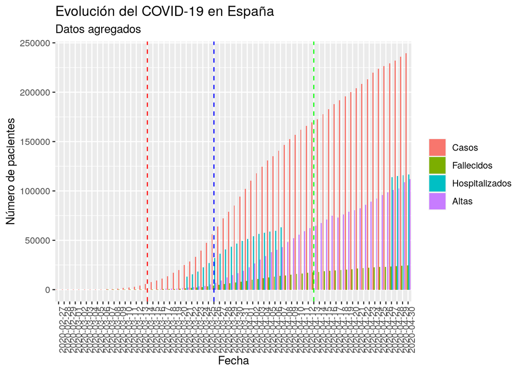

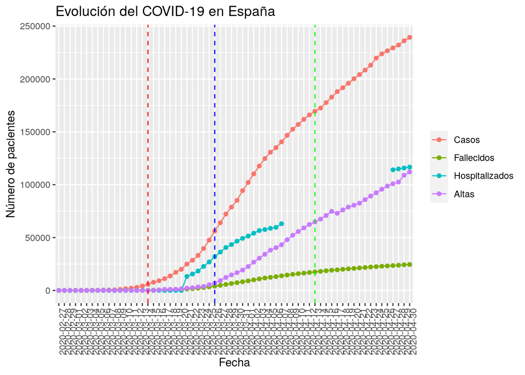

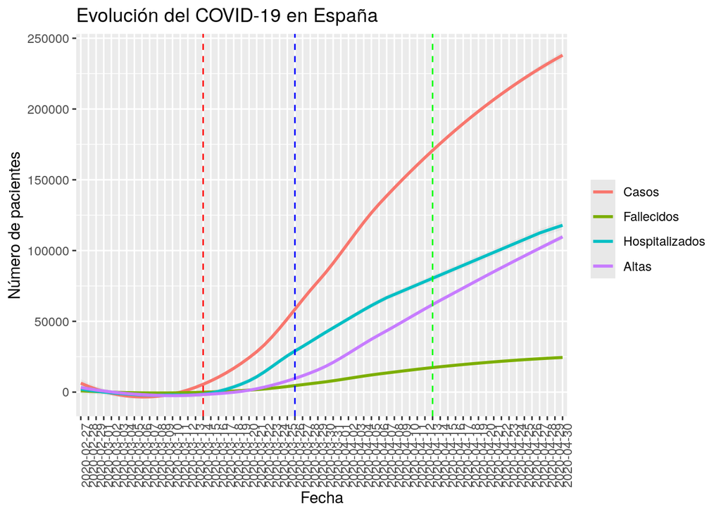

```r
global.ESP; global.raw; global.suavizado;
```

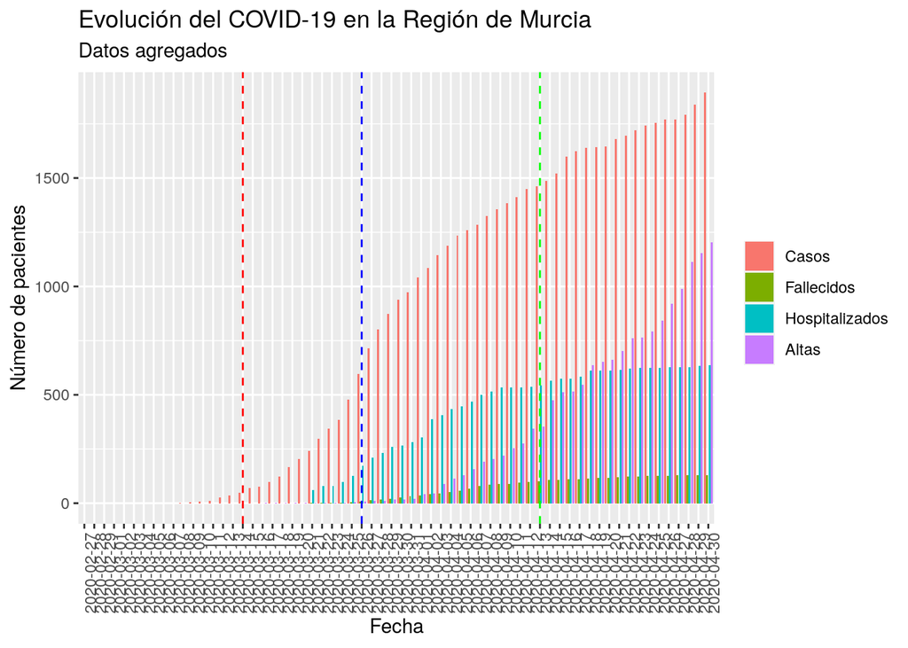

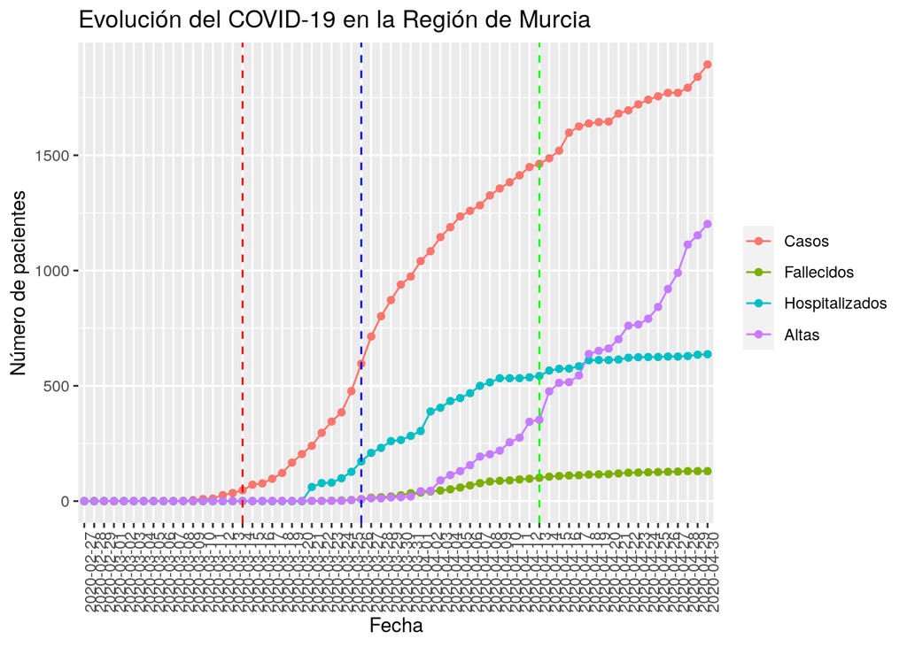

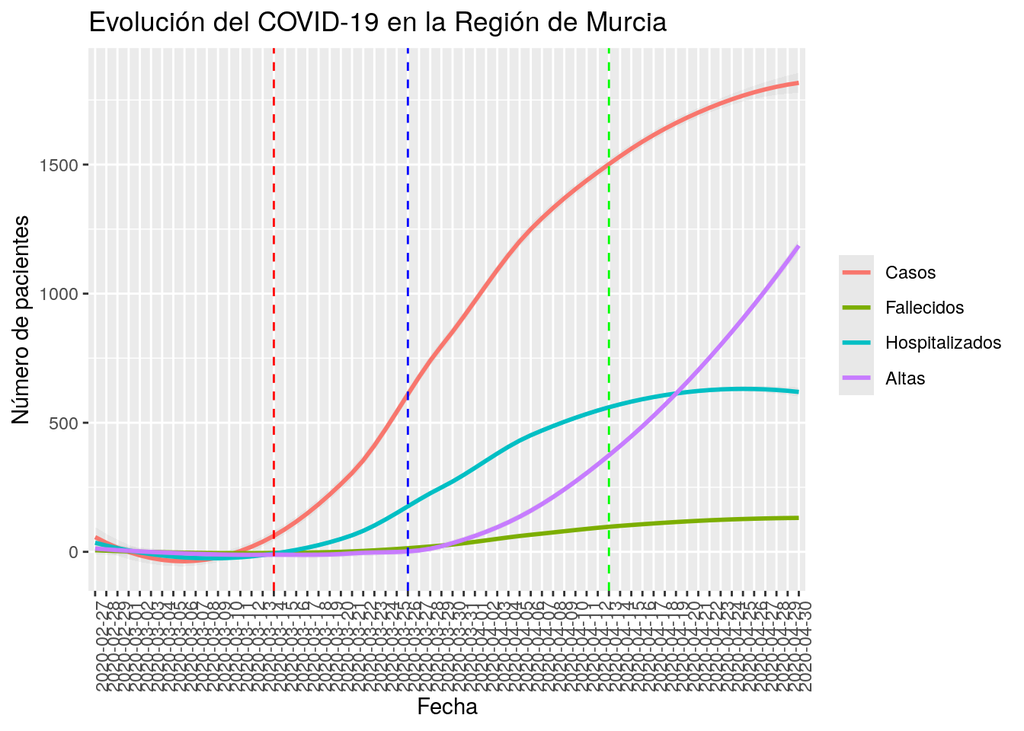

```r
global.CARM; CARM.raw; CARM.suavizado
```

### 3.2.2 Evolución desglosada

#### 3.2.2.1 Positivos

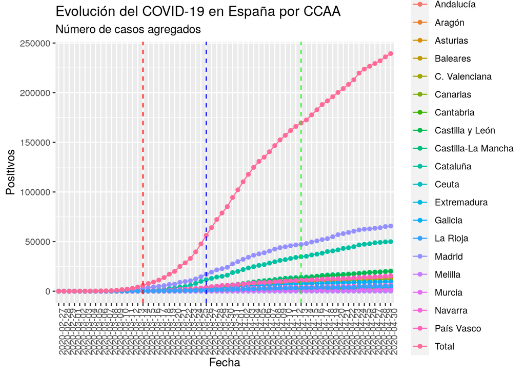

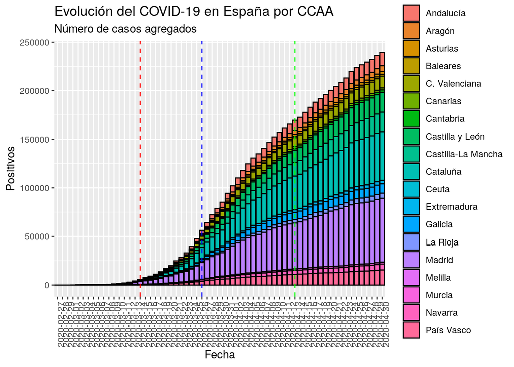

```r
casos.line; casos.bar
```

#### 3.2.2.2 Hospitalizados

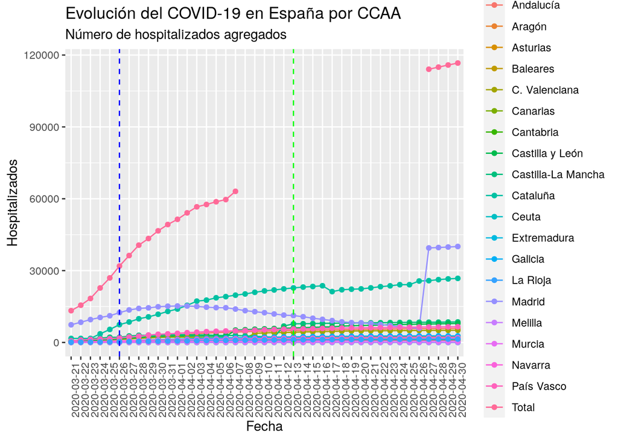

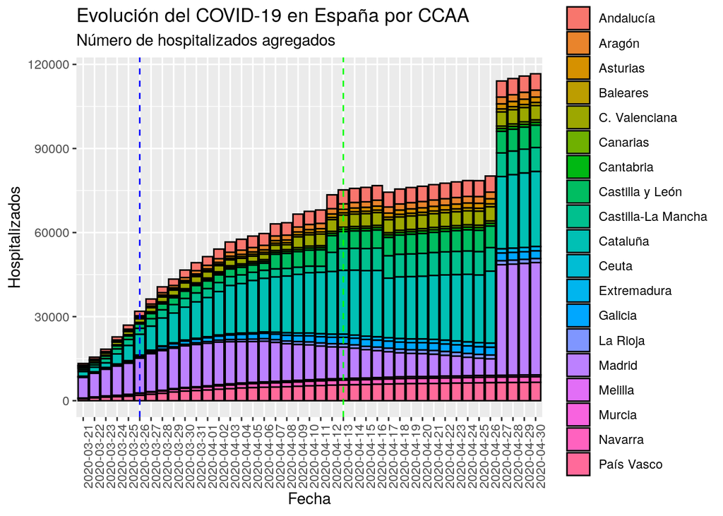

```r
hospitalizados.line; hospitalizados.bar
```

#### 3.2.2.3 Fallecidos

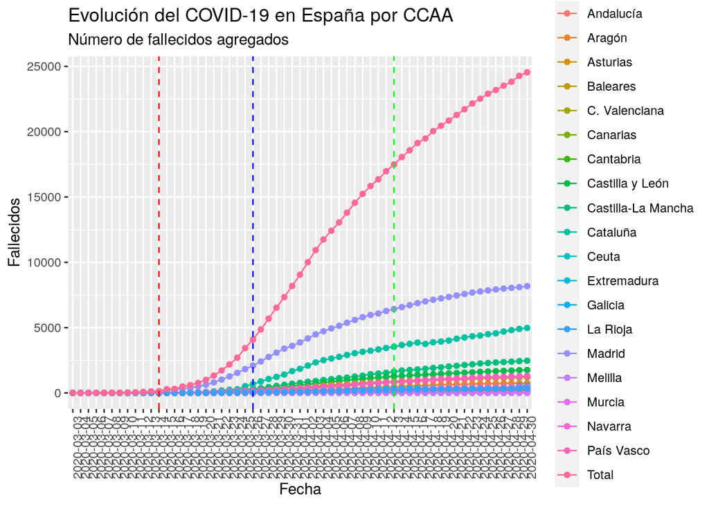

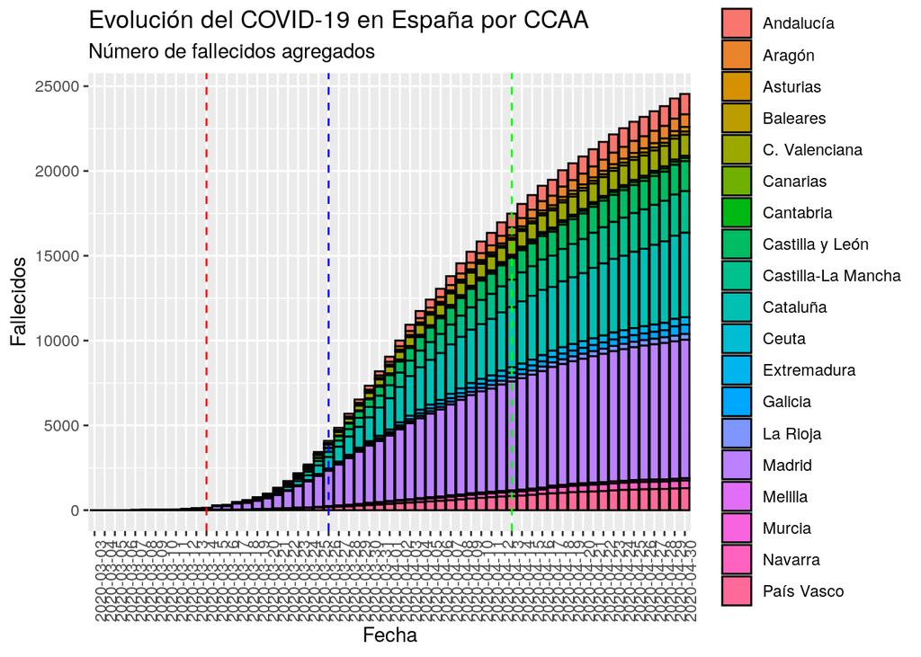

```r
fallecidos.line; fallecidos.bar
```

#### 3.2.2.4 Altas

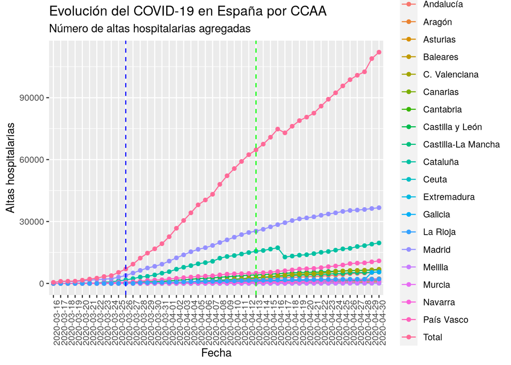

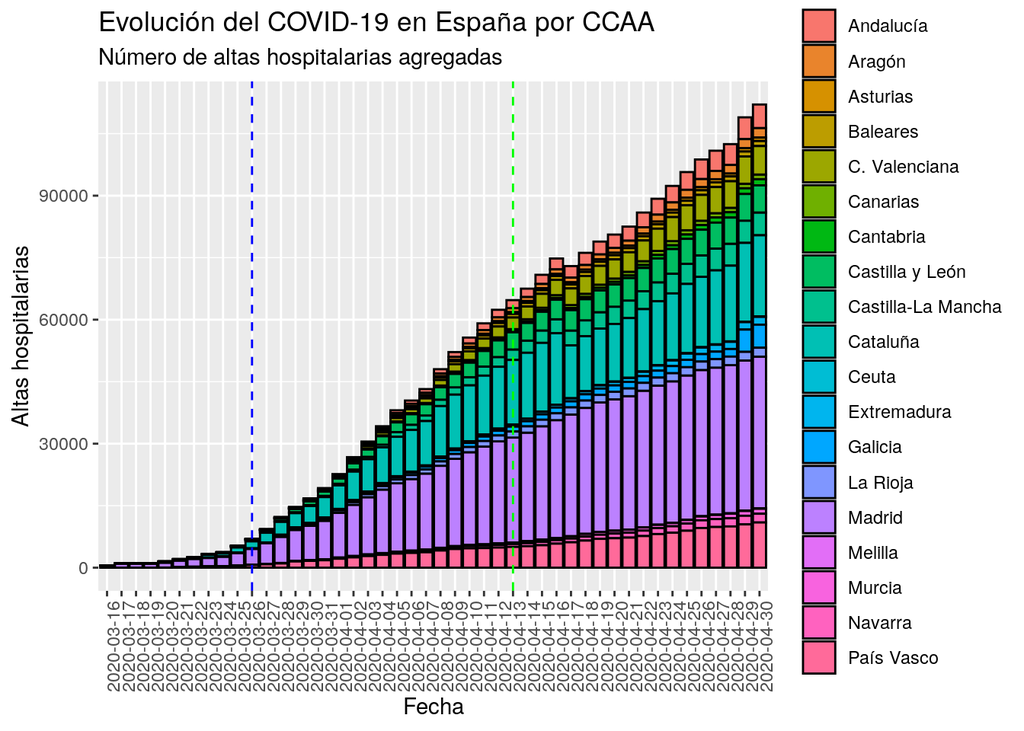

```r
altas.line; altas.bar
```

### 3.2.3 Velocidad

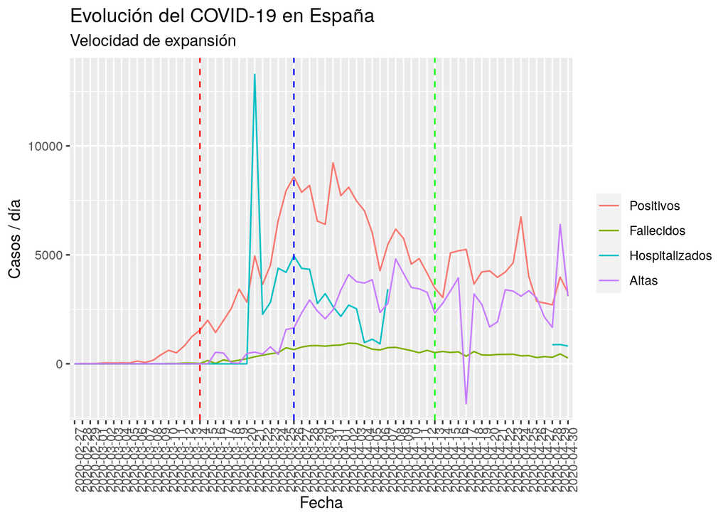

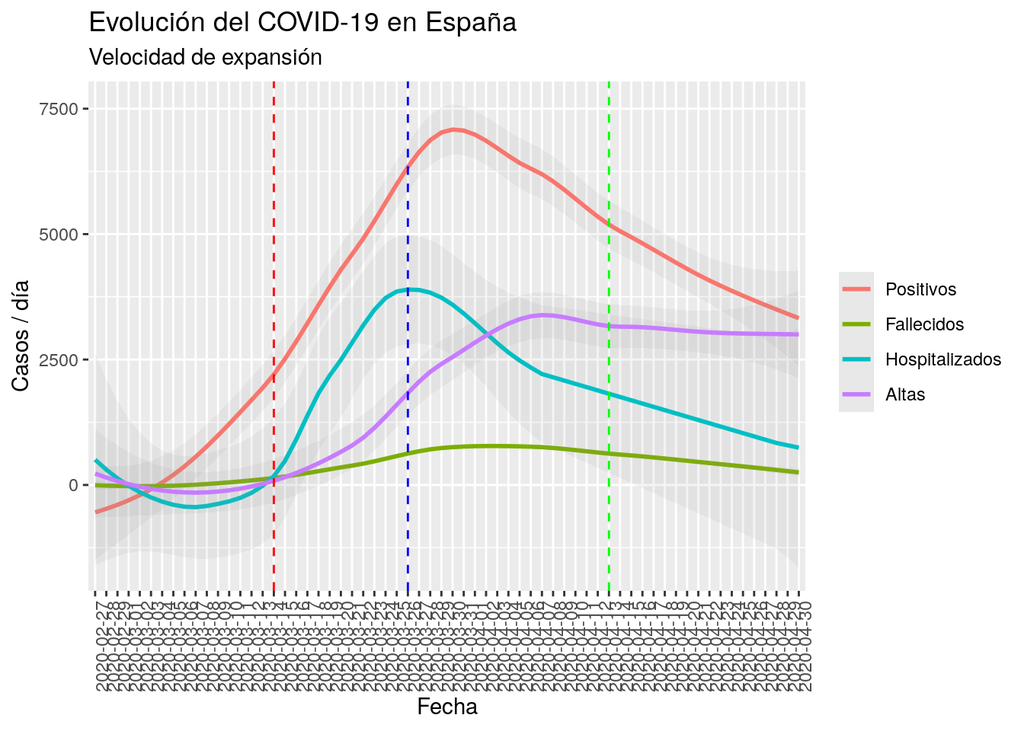

```r
vel.plot.raw; vel.plot.suavizado
```

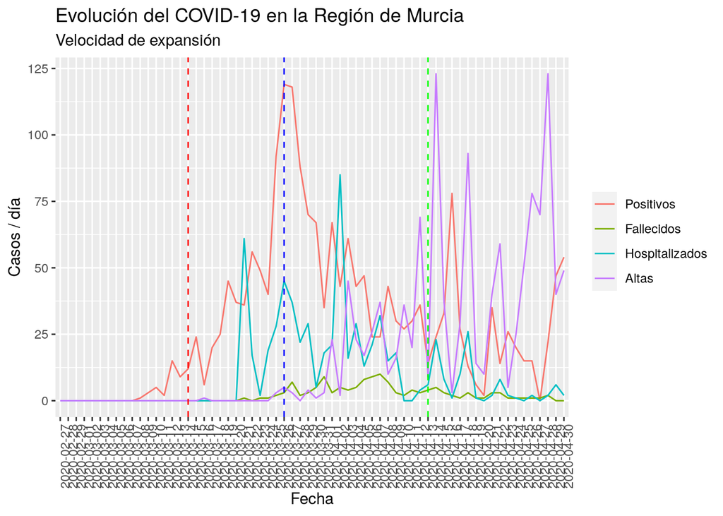

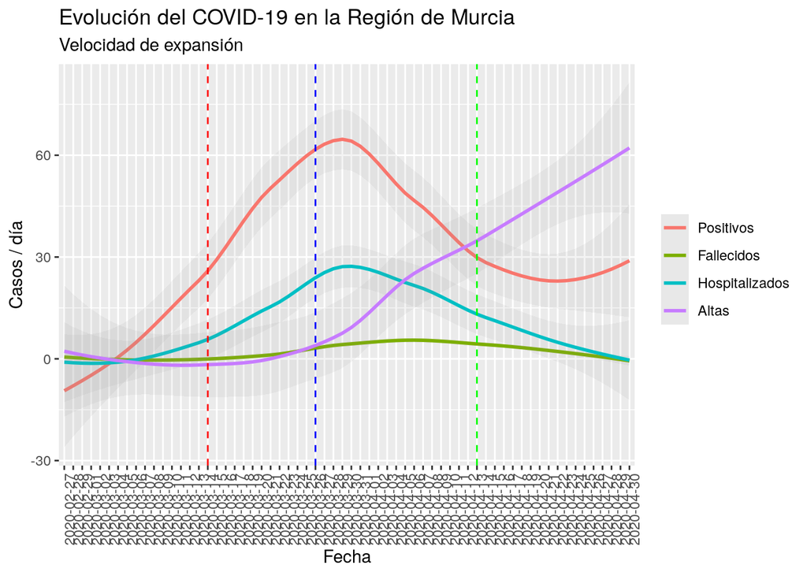

```r
vel.plot.CARM.raw; vel.plot.CARM.suavizado
```

## 3.3 Exportación

Los gráficos presentados anteriormente se exportan a la carpeta `Graficas` a una resolución de 1920x1080 px.

```r
if (dir.exists("Graficas") == F) {
  dir.create("Graficas")
}

# Gráficos globales
ggsave("global_raw.png",
       plot = global.raw,
       path = "./Graficas",
       width = 50.8,
       height = 28.58,
       units = 'cm',
       dpi = 300)
ggsave("global_smooth.png",
       plot = global.suavizado,
       path = "./Graficas",
       width = 50.8,
       height = 28.58,
       units = 'cm',
       dpi = 300)
ggsave("global_ESP.png",
       plot = global.ESP,
       path = "./Graficas",
       width = 50.8,
       height = 28.58,
       units = 'cm',
       dpi = 300)
ggsave("global_CARM.png",
       plot = global.CARM,
       path = "./Graficas",
       width = 50.8,
       height = 28.58,
       units = 'cm',
       dpi = 300)

# Evolución desglosada por factor

## Barplots
ggsave("casos_bar.png",
       plot = casos.bar,
       path = "./Graficas",
       width = 50.8,
       height = 28.58,
       units = 'cm',
       dpi = 300)

ggsave("hospitalizados_bar.png",
       plot = hospitalizados.bar,
       path = "./Graficas",
       width = 50.8,
       height = 28.58,
       units = 'cm',
       dpi = 300)

ggsave("fallecidos_bar.png",
       plot = fallecidos.bar,
       path = "./Graficas",
       width = 50.8,
       height = 28.58,
       units = 'cm',
       dpi = 300)

ggsave("altas_bar.png",
       plot = altas.bar,
       path = "./Graficas",
       width = 50.8,
       height = 28.58,
       units = 'cm',
       dpi = 300)

## Lineplots
ggsave("casos_line.png",
       plot = casos.line,
       path = "./Graficas",
       width = 50.8,
       height = 28.58,
       units = 'cm',
       dpi = 300)

ggsave("hospitalizados_line.png",
       plot = hospitalizados.line,
       path = "./Graficas",
       width = 50.8,
       height = 28.58,
       units = 'cm',
       dpi = 300)
ggsave("fallecidos_line.png",
       plot = fallecidos.line,
       path = "./Graficas",
       width = 50.8,
       height = 28.58,
       units = 'cm',
       dpi = 300)

ggsave("altas_line.png",
       plot = altas.line,
       path = "./Graficas",
       width = 50.8,
       height = 28.58,
       units = 'cm',
       dpi = 300)

# Plots de velocidad
ggsave("velocidad_raw.png",
       plot = vel.plot.raw,
       path = "./Graficas",
       width = 50.8,
       height = 28.58,
       units = 'cm',
       dpi = 300)

ggsave("velocidad_smooth.png",
       plot = vel.plot.suavizado,
       path = "./Graficas",
       width = 50.8,
       height = 28.58,
       units = 'cm',
       dpi = 300)
ggsave("velocidad_CARM_raw.png",
       plot = vel.plot.CARM.raw,
       path = "./Graficas",
       width = 50.8,
       height = 28.58,
       units = 'cm',
       dpi = 300)

ggsave("velocidad_CARM_smooth.png",
       plot = vel.plot.CARM.suavizado,
       path = "./Graficas",
       width = 50.8,
       height = 28.58,
       units = 'cm',
       dpi = 300)
```